# PredictingWithBoostingModel

Zhiming Guo and Brooke Anderson

August 7, 2016

```r
# Load required libraries

# Data wrangling
library(lubridate)
library(dplyr)
library(tidyr)
library(readr)

# For plotting
library(ggplot2)

# For bagging and random forest models
library(randomForest)
### For tuning models
library(caret)
```

## Data and Methods

```r
# Load and clean up data:
load("data-raw/ListOfAllHeatwaves.Rdata")
all.hws <- hw_data

hw <- all.hws %>%
  mutate(start.year = year(start.date))
colnames(hw) <- gsub(" ", ".", colnames(hw))
```

Some exploratory assessment of the training data.

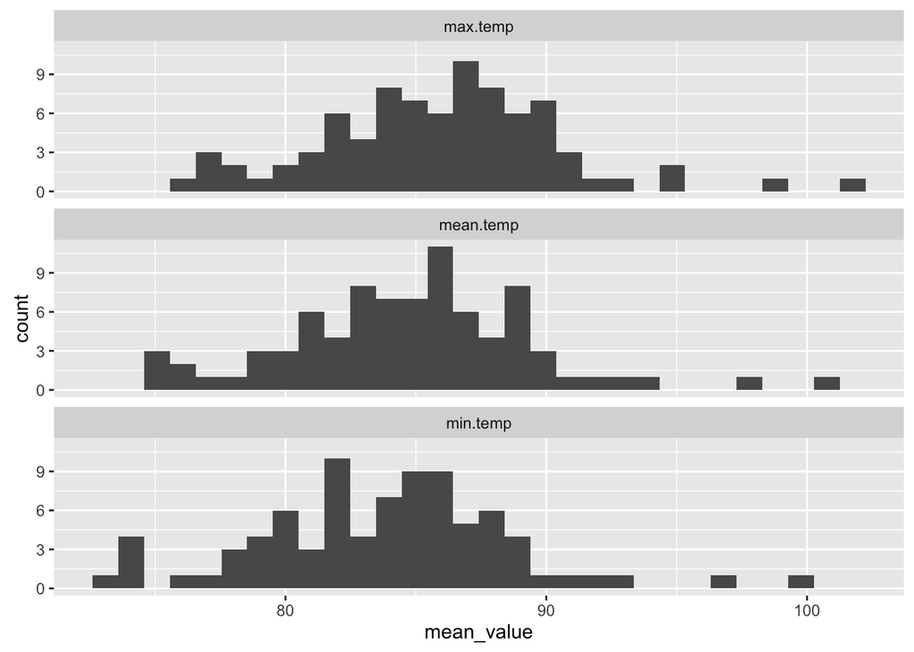

```r
library(maps)
us_map <- map_data("state")

## Here are the distributions of heatwave temperatures (absolute), city averages
hw %>%
  select(city, mean.temp, max.temp, min.temp) %>%
  gather(key = key, value = value, -city) %>%
  group_by(city, key) %>%
  summarize(mean_value = mean(value)) %>%
  ggplot(aes(x = mean_value)) +
  geom_histogram(bins = 30) +
  facet_wrap(~ key, ncol = 1)
```

```r
## Here are the cities with, on average, the hottest heatwaves (absolute temp)
hw %>%
  select(city, mean.temp, max.temp, min.temp) %>%
  gather(key = key, value = value, -city) %>%
  group_by(city, key) %>%
  summarize(mean_value = mean(value)) %>%
  ungroup() %>%
  spread(key, mean_value) %>%
  arrange(desc(mean.temp)) %>%
  slice(1:10)
```

```
## # A tibble: 10 × 4
##     city  max.temp mean.temp min.temp
##    <chr>     <dbl>     <dbl>    <dbl>
## 1   phoe 101.34146 100.29913 99.32927
## 2   lasv  98.90278  97.74285 96.54167
## 3   tucs  95.06897  93.88614 92.91379
## 4   bake  94.43590  93.21907 92.01282
## 5   dlft  92.76724  91.72800 90.89655
## 6   fres  92.05357  90.90179 89.60714
## 7   elpa  91.16667  90.20079 89.13333
## 8   tuls  91.12162  90.12901 89.22973
## 9   aust  90.59375  89.79974 89.18750
## 10  wich  90.28333  89.35532 88.40000
```

```r
## Here are the cities with, on average, the least hot heatwaves (absolute temp)
hw %>%
  select(city, mean.temp, max.temp, min.temp) %>%
  gather(key = key, value = value, -city) %>%
  group_by(city, key) %>%
  summarize(mean_value = mean(value)) %>%
  ungroup() %>%
  spread(key, mean_value) %>%
  arrange(mean.temp) %>%
  slice(1:10)
```

```
## # A tibble: 10 × 4
##     city max.temp mean.temp min.temp
##    <chr>    <dbl>     <dbl>    <dbl>
## 1   sanf 76.47561  74.65732 72.69512
## 2   seat 77.02857  75.41816 73.80000
## 3   taco 77.02857  75.41816 73.80000
## 4   sanj 77.26786  75.63700 73.94048
## 5   oakl 77.67905  76.06436 74.35923
## 6   colo 78.50000  77.48627 76.50000
## 7   sand 78.81081  77.67742 76.60811
## 8   port 80.38372  78.87791 77.59302
## 9     la 80.78205  79.23578 78.01282
## 10   wor 80.49145  79.39410 78.32692
```

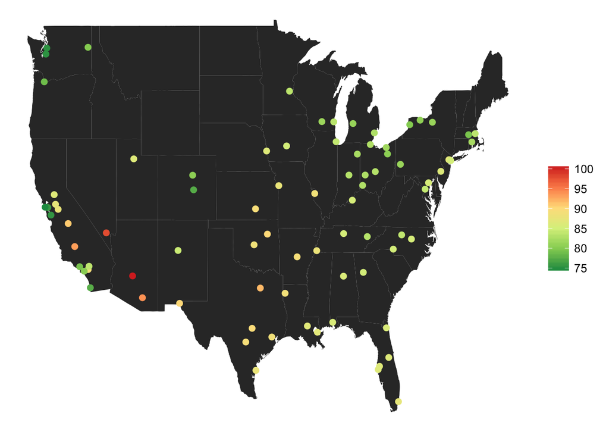

```r
## Here is a map of cities' average heatwave temperatures (absolute)
hw %>%
  select(city, mean.temp) %>%
  group_by(city) %>%
  summarize(mean_value = mean(mean.temp)) %>%
  left_join(read_csv("cities.csv"), by = "city") %>%
  ggplot(aes(x = long - 360, y = lat, color = mean_value, label = city)) +
  geom_polygon(data = us_map, aes(x = long, y = lat,
                                  group = group, color = NULL, label = NULL)) +
  geom_point(size = 2) +
  #geom_text(color = "black", alpha = 0.5) +
  scale_color_distiller(palette = "RdYlGn") +
  theme_void()
```

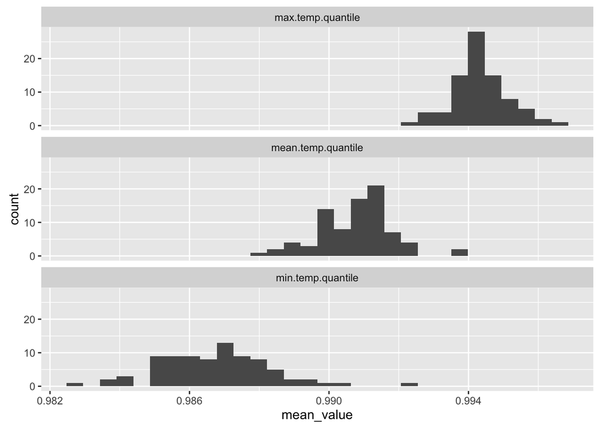

```r
## Here are the distributions of heatwave temperatures (relative), city averages
hw %>%
  select(city, mean.temp.quantile, max.temp.quantile, min.temp.quantile) %>%
  gather(key = key, value = value, -city) %>%
  group_by(city, key) %>%
  summarize(mean_value = mean(value)) %>%
  ggplot(aes(x = mean_value)) +
  geom_histogram(bins = 30) +
  facet_wrap(~ key, ncol = 1)
```

```r
## Here are the cities with, on average, the hottest heatwaves (relative temp)
hw %>%
  select(city, mean.temp.quantile, max.temp.quantile, min.temp.quantile) %>%
  gather(key = key, value = value, -city) %>%
  group_by(city, key) %>%
  summarize(mean_value = mean(value)) %>%
  ungroup() %>%
  spread(key, mean_value) %>%
  arrange(desc(mean.temp.quantile)) %>%
  slice(1:10)
```

```
## # A tibble: 10 × 4
##     city max.temp.quantile mean.temp.quantile min.temp.quantile
##    <chr>             <dbl>              <dbl>             <dbl>
## 1   orla         0.9965169          0.9936003         0.9904849
## 2   aust         0.9961410          0.9935879         0.9923721
## 3   miam         0.9957884          0.9924578         0.9898724
## 4   oakl         0.9945751          0.9921411         0.9878184
## 5   seat         0.9947468          0.9920749         0.9882956
## 6   taco         0.9947468          0.9920749         0.9882956
## 7   syra         0.9957445          0.9920509         0.9875889
## 8   indi         0.9954402          0.9919959         0.9878823
## 9    kan         0.9948928          0.9918944         0.9884059
## 10  batr         0.9959701          0.9918425         0.9896207
```

```r
## Here are the cities with, on average, the least hot heatwaves (relative temp)
hw %>%
  select(city, mean.temp.quantile, max.temp.quantile, min.temp.quantile) %>%
  gather(key = key, value = value, -city) %>%
  group_by(city, key) %>%
  summarize(mean_value = mean(value)) %>%
  ungroup() %>%
  spread(key, mean_value) %>%
  arrange(mean.temp.quantile) %>%
  slice(1:10)
```

```
## # A tibble: 10 × 4
##     city max.temp.quantile mean.temp.quantile min.temp.quantile
##    <chr>             <dbl>              <dbl>             <dbl>
## 1   atla         0.9927223          0.9878552         0.9826016
## 2   lasv         0.9922294          0.9883682         0.9834695
## 3   loui         0.9926331          0.9884366         0.9839863
## 4   nash         0.9932565          0.9888120         0.9835799
## 5   knox         0.9946458          0.9889542         0.9840740
## 6   phoe         0.9933366          0.9889682         0.9843080
## 7     no         0.9940914          0.9891688         0.9857139
## 8   memp         0.9930980          0.9891895         0.9862680
## 9   tuls         0.9947309          0.9892164         0.9850105
## 10  char         0.9928999          0.9895425         0.9851189
```

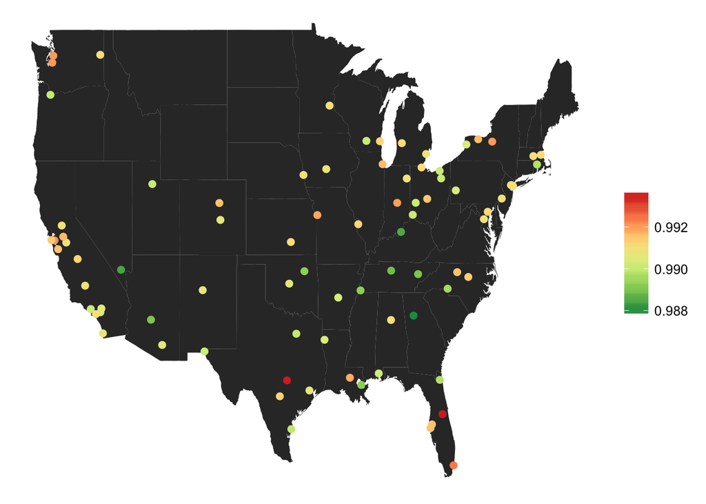

```r
## Here is a map of cities' average heatwave temperatures (relative)
hw %>%
  select(city, mean.temp.quantile) %>%
  group_by(city) %>%
  summarize(mean_value = mean(mean.temp.quantile)) %>%
  left_join(read_csv("cities.csv"), by = "city") %>%
  ggplot(aes(x = long - 360, y = lat, color = mean_value, label = city)) +
  geom_polygon(data = us_map, aes(x = long, y = lat,
                                  group = group, color = NULL, label = NULL)) +
  geom_point(size = 2) +
  #geom_text(color = "black", alpha = 0.5) +
  scale_color_distiller(palette = "RdYlGn") +
  theme_void()
```

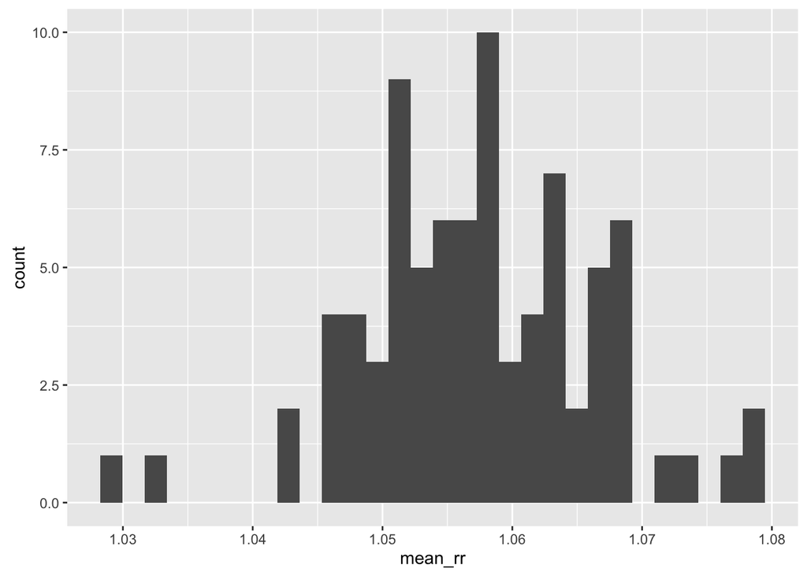

```r
## Here are the distributions of heatwave effects, city averages
hw %>%
  select(city, post.estimate) %>%
  group_by(city) %>%
  summarize(mean_value = mean(post.estimate)) %>%
  mutate(mean_rr = exp(mean_value)) %>%
  ggplot(aes(x = mean_rr)) +
  geom_histogram(bins = 30)
```

```r
## Here are the cities with the largest heatwave effects, city averages
hw %>%
  select(city, post.estimate) %>%
  group_by(city) %>%
  summarize(mean_value = mean(post.estimate)) %>%
  mutate(mean_rr = exp(mean_value)) %>%
  arrange(desc(mean_rr)) %>%
  select(-mean_value) %>%
  slice(1:10)
```

```
## # A tibble: 10 × 2
##     city  mean_rr
##    <chr>    <dbl>
## 1     ny 1.079325
## 2   balt 1.078132
## 3    det 1.077094
## 4   taco 1.073827
## 5   roch 1.071952
## 6     la 1.069123
## 7   port 1.068913
## 8   oakl 1.068749
## 9   indi 1.068470
## 10  minn 1.068421
```

```r
## Here are the cities with the smallest heatwave effects, city averages
hw %>%
  select(city, post.estimate) %>%
  group_by(city) %>%
  summarize(mean_value = mean(post.estimate)) %>%
  mutate(mean_rr = exp(mean_value)) %>%
  arrange(mean_rr) %>%
  select(-mean_value) %>%
  slice(1:10)
```

```
## # A tibble: 10 × 2
##     city  mean_rr
##    <chr>    <dbl>
## 1   dlft 1.029831
## 2   rive 1.031798
## 3   sana 1.042185
## 4   hous 1.043029
## 5   sand 1.045683
## 6   char 1.045895
## 7   birm 1.046759
## 8   albu 1.046890
## 9   tamp 1.047399
## 10  okla 1.047849
```

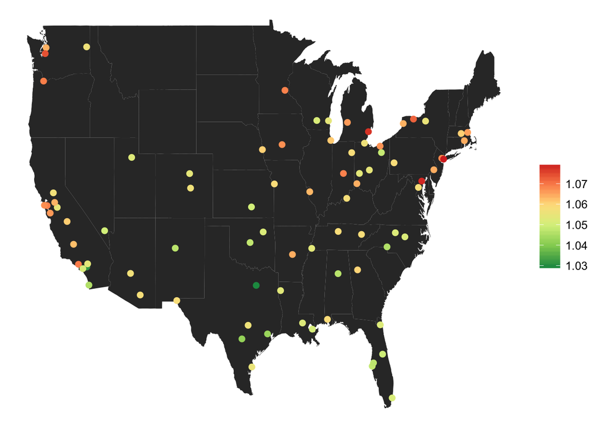

```r
## Here is a map of average heatwave effects
hw %>%
  select(city, post.estimate) %>%
  group_by(city) %>%
  summarize(mean_value = mean(post.estimate)) %>%
  mutate(mean_rr = exp(mean_value)) %>%
  left_join(read_csv("cities.csv"), by = "city") %>%
  ggplot(aes(x = long - 360, y = lat, color = mean_rr, label = city)) +
  geom_polygon(data = us_map, aes(x = long, y = lat,
                                  group = group, color = NULL, label = NULL)) +
  geom_point(size = 2) +
  #geom_text(color = "black", alpha = 0.5) +
  scale_color_distiller(palette = "RdYlGn") +
  theme_void()
```

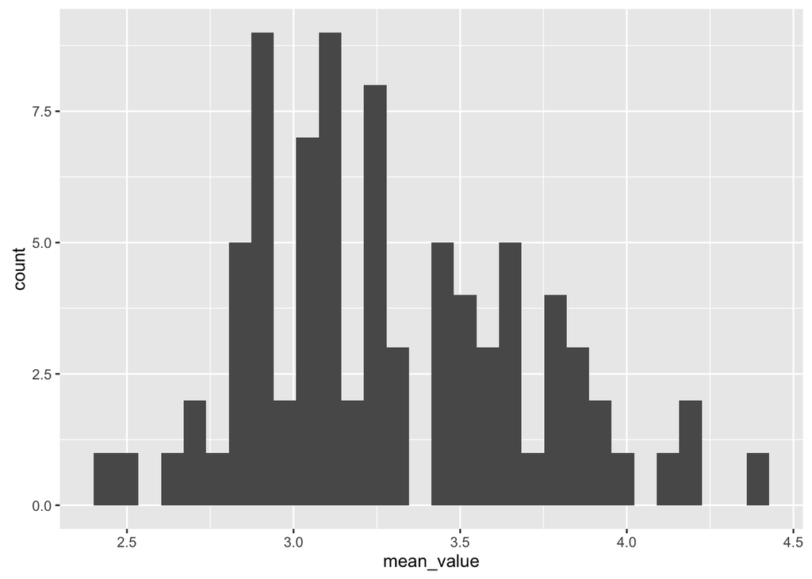

```r
## Here are the distributions of heatwave lengths, city averages
hw %>%
  select(city, length) %>%
  group_by(city) %>%
  summarize(mean_value = mean(length)) %>%
  ggplot(aes(x = mean_value)) +
  geom_histogram(bins = 30)
```

```r
## Here are the cities with the longest heatwaves, city averages
hw %>%
  select(city, length) %>%
  group_by(city) %>%
  summarize(mean_value = mean(length)) %>%
  arrange(desc(mean_value)) %>%
  slice(1:10)
```

```
## # A tibble: 10 × 2
##     city mean_value
##    <chr>      <dbl>
## 1   rive   4.392857
## 2   lasv   4.222222
## 3   dlft   4.172414
## 4   okla   4.096774
## 5   fres   3.964286
## 6    shr   3.939394
## 7   sanb   3.931034
## 8     no   3.868421
## 9   batr   3.838710
## 10  wich   3.833333
```

```r
## Here are the cities with the shortest heatwaves, city averages
hw %>%
  select(city, length) %>%
  group_by(city) %>%
  summarize(mean_value = mean(length)) %>%
  arrange(mean_value) %>%
  slice(1:10)
```

```
## # A tibble: 10 × 2
##     city mean_value
##    <chr>      <dbl>
## 1   oakl   2.432432
## 2   sanj   2.476190
## 3   sanf   2.609756
## 4   miam   2.714286
## 5   bost   2.736842
## 6   milw   2.771429
## 7   seat   2.828571
## 8   taco   2.828571
## 9   port   2.837209
## 10  gdrp   2.842105
```

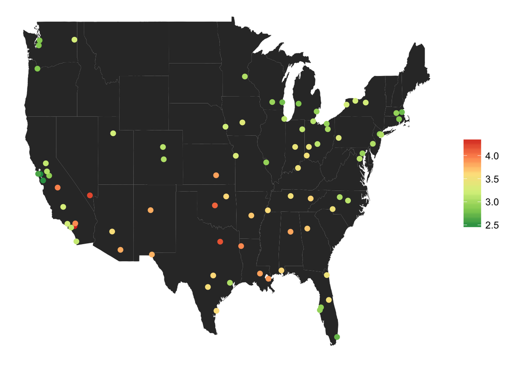

```r
## Here is a map of average heatwave lengths
hw %>%
  select(city, length) %>%
  group_by(city) %>%
  summarize(mean_value = mean(length)) %>%
  left_join(read_csv("cities.csv"), by = "city") %>%
  ggplot(aes(x = long - 360, y = lat, color = mean_value, label = city)) +
  geom_polygon(data = us_map, aes(x = long, y = lat,
                                  group = group, color = NULL, label = NULL)) +
  geom_point(size = 2) +
  #geom_text(color = "black", alpha = 0.5) +
  scale_color_distiller(palette = "RdYlGn") +
  theme_void()
```

The training data used to develop the predictive model were from 83 US communities over the years 1987-2005. This training dataset included all heatwaves in these communities over this time period, a total of 2,980 heatwaves.

```r
training_data <- hw %>%
  dplyr::select(mean.temp, max.temp, min.temp, length, start.doy, start.month,
                days.above.80, days.above.85, days.above.90, days.above.95,
                days.above.99th, days.above.99.5th, first.in.season,
                mean.temp.quantile, max.temp.quantile, min.temp.quantile,
                mean.temp.1, mean.summer.temp, pop100, pop.density,
                post.estimate)
```

Fitting a random forest model, with tuning:

```r
# Use 10-fold cross validation for tuning to find the best `mtry`
fitControl <- trainControl(method = "cv", number = 10)

set.seed(1)
tuning.rf.hw <- train(post.estimate ~ ., data = training_data,
                   method = "rf", trControl = fitControl, ntree = 1000,
                   importance = TRUE, metric = "RMSE",
                   maximize = FALSE, tuneLength = 5)
save(tuning.rf.hw, file = "tuning.rf.hw.RData")
rf_mod <- tuning.rf.hw$finalModel
save(rf_mod, file = "rf_mod.RData")
```

```r
load("tuning.rf.hw.RData")
load("rf_mod.RData")
```

See if pre-processing (center, scale, and Box Cox transformation to prevent potential problems from skewness) improve model performance:

```r
# Use 10-fold cross validation for tuning to find the best `mtry`
fitControl <- trainControl(method = "cv", number = 10)

set.seed(1)
tuning.rf.hw.pre <- train(post.estimate ~ ., data = training_data,
                   method = "rf", trControl = fitControl, ntree = 100,
                   importance = TRUE, metric = "RMSE",
                   maximize = FALSE, tuneLength = 5,
                   preProcess = c("center", "scale", "BoxCox"))
save(tuning.rf.hw.pre, file = "tuning.rf.hw.pre.RData")
```

Basic model for comparison (always predicts mean log RR as heatwave effect):

```r
fitControl <- trainControl(method = "cv", number = 10)
basic_mod <- train(post.estimate ~ 1, data = training_data,
                   method = "glm", family = "gaussian",
                   trControl = fitControl)

save(basic_mod, file = "basic_mod.RData")
```

```r
# Basic model coefficients for Fig. 1 histogram
load("basic_mod.RData")
basic_mod
```

[output not shown]

```
## Generalized Linear Model
##
## 2980 samples
##   20 predictor
##
## No pre-processing
## Resampling: Cross-Validated (10 fold)
## Summary of sample sizes: 2682, 2681, 2682, 2682, 2682, 2681, ...
## Resampling results:
##
##   RMSE        Rsquared
##   0.03165954  NaN
##
##
```

```r
coef(basic_mod$finalModel)
```

```
## (Intercept)
##  0.05615617
```

```r
exp(coef(basic_mod$finalModel))
```

```
## (Intercept)
##    1.057763
```

Here are average values of RMSE in hold-out samples, averaged across the 10 cross-validations, for the best random forest model and for the basic model:

```r
min(tuning.rf.hw$results$RMSE)
```

```
## [1] 0.03011299
```

```r
basic_mod$results$RMSE
```

```
## [1] 0.03165954
```

Performance does not improve with pre-processing (Box Cox, centering, and scaling [note: I originally checked this using 100-tree random forests for both with and without pre-processing, and still found performance did not improve with pre-processing]):

```r
load("tuning.rf.hw.pre.RData")
min(tuning.rf.hw.pre$results$RMSE)
```

```
## [1] 0.0302604
```

Here are the results from that tuning process:

```r
tuning.rf.hw
```

```
## Random Forest
##
## 2980 samples
##   20 predictor
##
## No pre-processing
## Resampling: Cross-Validated (10 fold)
## Summary of sample sizes: 2681, 2681, 2682, 2681, 2682, 2684, ...
## Resampling results across tuning parameters:
##
##   mtry  RMSE        Rsquared
##    2    0.03011299  0.09679614
##    6    0.03028751  0.09656850
##   11    0.03040613  0.09471080
##   15    0.03045567  0.09499287
##   20    0.03049256  0.09518342
##
## RMSE was used to select the optimal model using  the smallest value.
## The final value used for the model was mtry = 2.
```

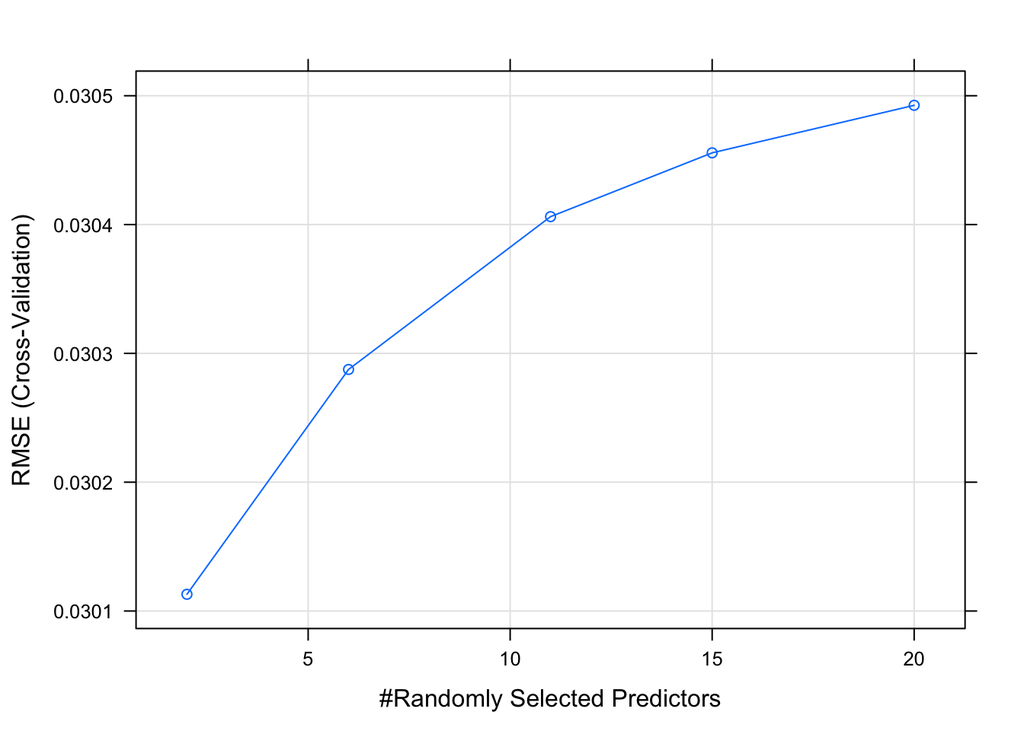

```r
plot(tuning.rf.hw)
```

Based on this tuning, the best value for `mtry` in the random forest model for this outcome is 2. (BA: Note– in my revised version, I’m using the training data to show performance– estimated RMSE, etc., are going to be more accurate from the cross-validation, because here we’re showing how well the model works on the data we trained it on, so it’s over-optimistic.)

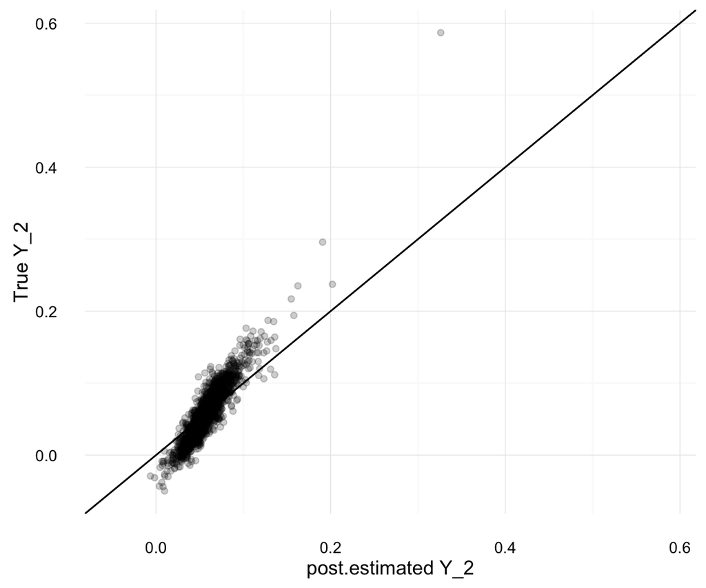

```r
yhat.rf <- predict(tuning.rf.hw$finalModel, newdata = training_data)

to_plot <- data.frame(post.estimated_y2 = yhat.rf,
                      true_y2 = training_data$post.estimate)
ggplot(to_plot, aes(x = post.estimated_y2, y = true_y2)) +
  geom_point(alpha = 0.2) +
  xlim(range(to_plot)) + ylim(range(to_plot)) +
  theme_minimal() +
  geom_abline(intercept = 0, slope = 1) +
  xlab("post.estimated Y_2") + ylab("True Y_2")
```

The mean squared error for this model (against the training data, when fit with that data; for OOB estimated RMSE, see the results from cross-validation above) was 2.962820810^{-4}.

Here are the variable importance plots:

```r
importance(tuning.rf.hw$finalModel)
```

```
##                      %IncMSE IncNodePurity
## mean.temp          12.198398    0.17580136
## max.temp            8.189293    0.15846716
## min.temp            8.136877    0.13139970
## length             13.544060    0.08969748
## start.doy          13.614501    0.18316880
## start.month        10.234235    0.06184759
## days.above.80      18.015766    0.09691408
## days.above.85      12.397389    0.07058563
## days.above.90       4.859718    0.05643950
## days.above.95       7.208178    0.01204790
## days.above.99th    13.906136    0.08860938
## days.above.99.5th  11.741351    0.07074282
## first.in.season     7.893256    0.03685972
## mean.temp.quantile 19.511842    0.18982454
## max.temp.quantile  17.784051    0.16818850
## min.temp.quantile  13.751175    0.15326276
## mean.temp.1        13.789351    0.14542404
## mean.summer.temp   12.542337    0.13716069
## pop100             15.570082    0.16878620
## pop.density        15.183167    0.14233355
```

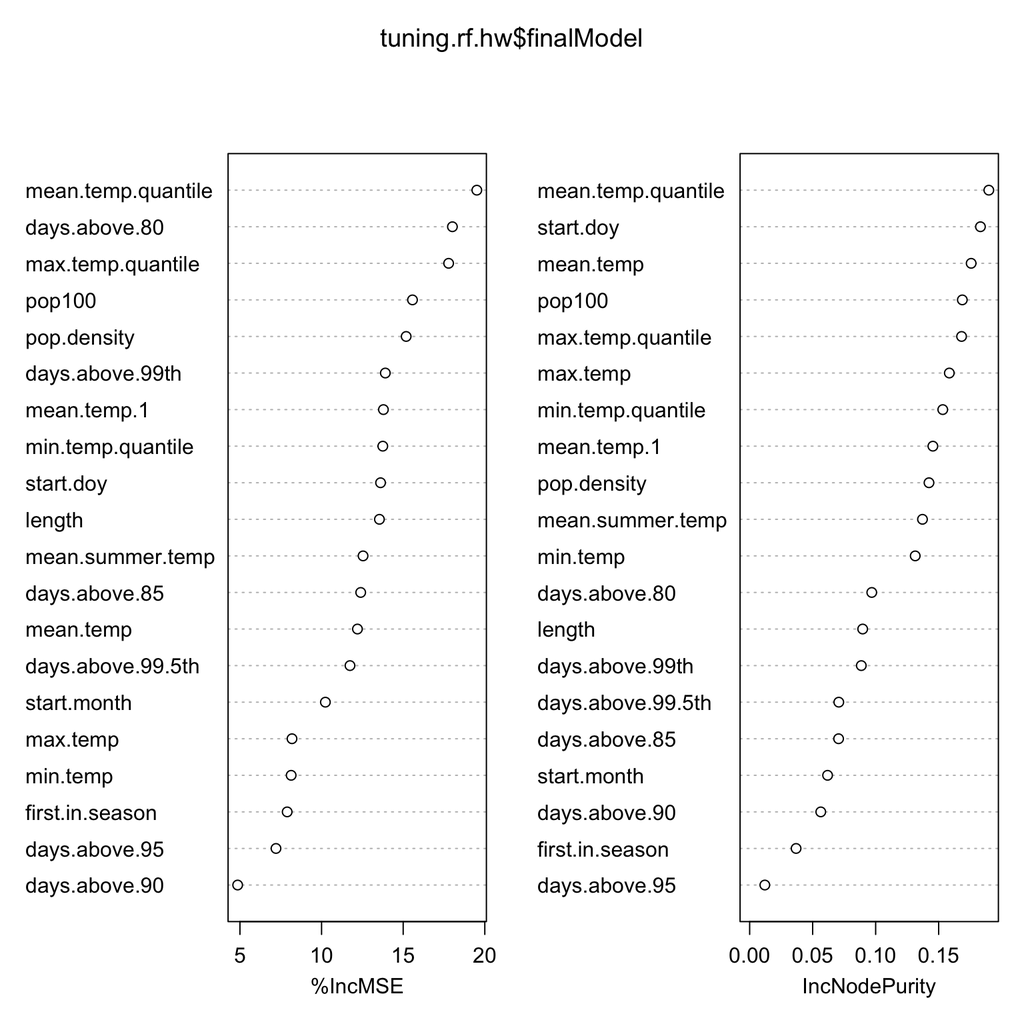

```r
varImpPlot(tuning.rf.hw$finalModel)
```

Determine average daily mortality for each community:

```r
library(futureheatwaves)

cities <- gsub(".rds", "", list.files("~/tmp/NMMAPS"))

calc_mort <- function(city){
  print(city)

  city_df <- readRDS(paste0("~/tmp/NMMAPS/", city, ".rds")) %>%
    dplyr::mutate(death = death + accident) %>%
    dplyr::group_by(date) %>%
    dplyr::summarize(death = sum(death),
                     tmpd = first(tmpd)) %>%
    dplyr::ungroup()

  city_hws <- IDHeatwavesCPPwrapper(threshold = quantile(city_df$tmpd, 0.98,
                                                         na.rm = TRUE),
                                    datafr = select(city_df, date, tmpd),
                                    numDays = 2) %>%
    dplyr::select(date, hw)

  city_df <- city_df %>%
    dplyr::left_join(city_hws, by = "date") %>%
    dplyr::filter(hw == 0) %>%
    dplyr::summarize(mean_death = mean(death))

  return(city_df$mean_death)
}

calc_total_mort <- function(city){
  print(city)

  city_df <- readRDS(paste0("~/tmp/NMMAPS/", city, ".rds")) %>%
    dplyr::mutate(death = death + accident) %>%
    dplyr::group_by(date) %>%
    dplyr::summarize(death = sum(death),
                     tmpd = first(tmpd)) %>%
    dplyr::ungroup()

  study_years <- length(unique(lubridate::year(city_df$date)))
  total_deaths <- sum(city_df$death) / 19 # average deaths per year

  return(total_deaths)
}

county_pops <- read.csv("nmmaps_counties.csv", as.is = TRUE) %>%
  select(city, pop) %>%
  group_by(city) %>%
  summarize(pop = sum(pop))

# `base_mort` is the average daily mortality on non-heat wave days
# `tot_mort` is the average total yearly mortality (heat wave and non-
# heat wave days)
base_deaths <- data.frame(city = cities,
                          base_mort = sapply(cities, calc_mort),
                          tot_mort = sapply(cities, calc_total_mort),
                          stringsAsFactors = FALSE)
base_deaths <- base_deaths %>%
  left_join(county_pops, by = "city") %>%
  mutate(mort_rate = base_mort / pop,
         tot_year_mort_rate = tot_mort / pop)

save(base_deaths, file = "base_deaths.RData")
```

Here are some summaries on total mortalities in the historical data

```r
load("base_deaths.RData")

## Cities with highest total mortality per year
base_deaths %>%
  arrange(desc(tot_mort)) %>%
  slice(1:10) %>%
  select(city, base_mort, tot_mort, pop)
```

```
##    city base_mort tot_mort     pop
## 1    ny 188.12748 68720.58 8931737
## 2    la 153.97711 56231.11 9519338
## 3  chic 116.54253 42589.79 5376741
## 4  dlft  59.41399 21696.58 4199873
## 5  phoe  50.80527 18564.05 3072149
## 6  sand  47.58244 17368.21 2813833
## 7   det  47.08504 17217.63 2061162
## 8  miam  47.08444 17197.26 2253362
## 9  hous  46.59261 17007.26 3400578
## 10 phil  42.35300 15475.16 1517550
```

```r
## Cities with highest mortality per person (average on non-heat wave days)
base_deaths %>%
  arrange(desc(mort_rate)) %>%
  slice(1:10) %>%
  select(city, mort_rate, tot_year_mort_rate, pop)
```

```
##    city    mort_rate tot_year_mort_rate     pop
## 1  stpe 3.432707e-05        0.012531301  921482
## 2  balt 3.062959e-05        0.011208140  635154
## 3  pitt 3.040590e-05        0.011101340 1281666
## 4  john 2.812600e-05        0.010263982  152598
## 5  stlo 2.805425e-05        0.010260308  348189
## 6  phil 2.790880e-05        0.010197462 1517550
## 7  clev 2.741643e-05        0.010015562 1393978
## 8  birm 2.737416e-05        0.009992056  662047
## 9  buff 2.726107e-05        0.009957222  950265
## 10 evan 2.698202e-05        0.009846877  171922
```

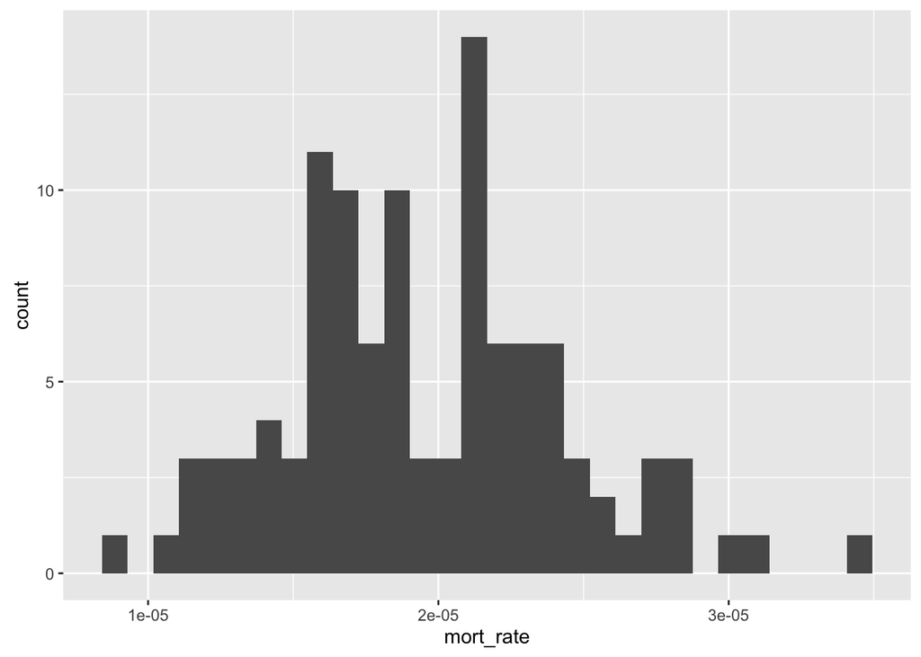

```r
## Here is the distribution of baseline (i.e., for non-heatwave days) daily mortality rate
## per person in the study cities
library(ggplot2)
ggplot(base_deaths, aes(x = mort_rate)) + geom_histogram()
```

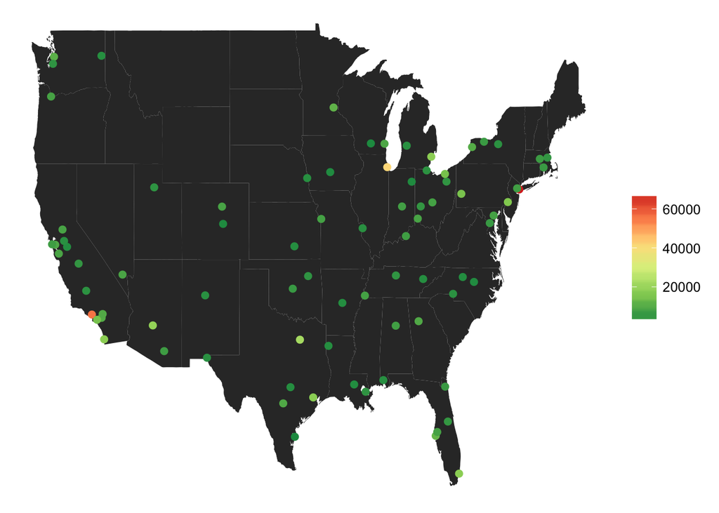

```r
## Here is a map of total mortality rates
base_deaths %>%
  right_join(read_csv("cities.csv"), by = "city") %>%
  ggplot(aes(x = long - 360, y = lat, color = tot_mort)) +
  geom_polygon(data = us_map, aes(x = long, y = lat,
                                  group = group, color = NULL, label = NULL)) +
  geom_point(size = 2) +
  #geom_text(color = "black", alpha = 0.5) +
  scale_color_distiller(palette = "RdYlGn") +
  theme_void()
```

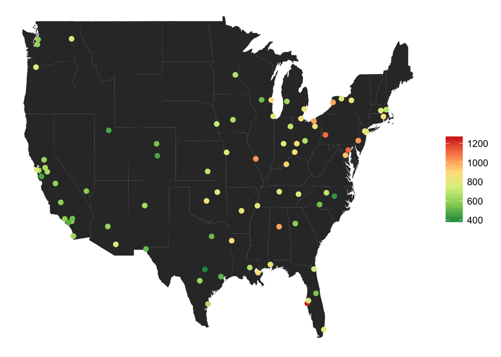

```r
## Here is a map of yearly total mortality rates per person
base_deaths %>%
  right_join(read_csv("cities.csv"), by = "city") %>%
  ggplot(aes(x = long - 360, y = lat, color = tot_year_mort_rate * 100000)) +
  geom_polygon(data = us_map, aes(x = long, y = lat,
                                  group = group, color = NULL, label = NULL)) +
  geom_point(size = 2) +
  #geom_text(color = "black", alpha = 0.5) +
  scale_color_distiller(palette = "RdYlGn") +
  theme_void()
```

Here is the code to predict from this model:

```r
proj_hws <- read.table("projected_heatwaves.txt", header = TRUE, as.is = TRUE)
proj_pops <- read.csv("projected_populations.csv", header = TRUE, as.is = TRUE)
land_area <- read.csv("land_area.csv", header = TRUE, as.is = TRUE)
load("base_deaths.RData")

proj_pops <- group_by(proj_pops, city) %>%
        summarise(pop100 = sum(SSP5)) %>%
        left_join(land_area, by = "city") %>%
        mutate(pop.density = pop100 / arealand) %>%
        dplyr::select(-arealand) %>%
  mutate(city = as.character(city))

## Here are expected yearly numbers of deaths in some of the larger cities
proj_pops %>%
  left_join(base_deaths, by = "city") %>%
  mutate(expected_yearly_mort = tot_year_mort_rate * pop) %>%
  arrange(desc(expected_yearly_mort)) %>%
  select(city, expected_yearly_mort) %>%
  slice(1:10)
```

```
## # A tibble: 10 × 2
##     city expected_yearly_mort
##    <chr>                <dbl>
## 1     ny             68720.58
## 2     la             56231.11
## 3   chic             42589.79
## 4   dlft             21696.58
## 5   phoe             18564.05
## 6   sand             17368.21
## 7    det             17217.63
## 8   miam             17197.26
## 9   hous             17007.26
## 10  phil             15475.16
```

```r
## Here is the total expected yearly deaths in all the cities, based on SSP5
proj_pops %>%
  left_join(base_deaths, by = "city") %>%
  mutate(expected_yearly_mort = tot_year_mort_rate * pop) %>%
  summarize(expected_yearly_mort = sum(expected_yearly_mort),
            expect_20_yr_mort = round(20 * sum(expected_yearly_mort)))
```

[output not shown]

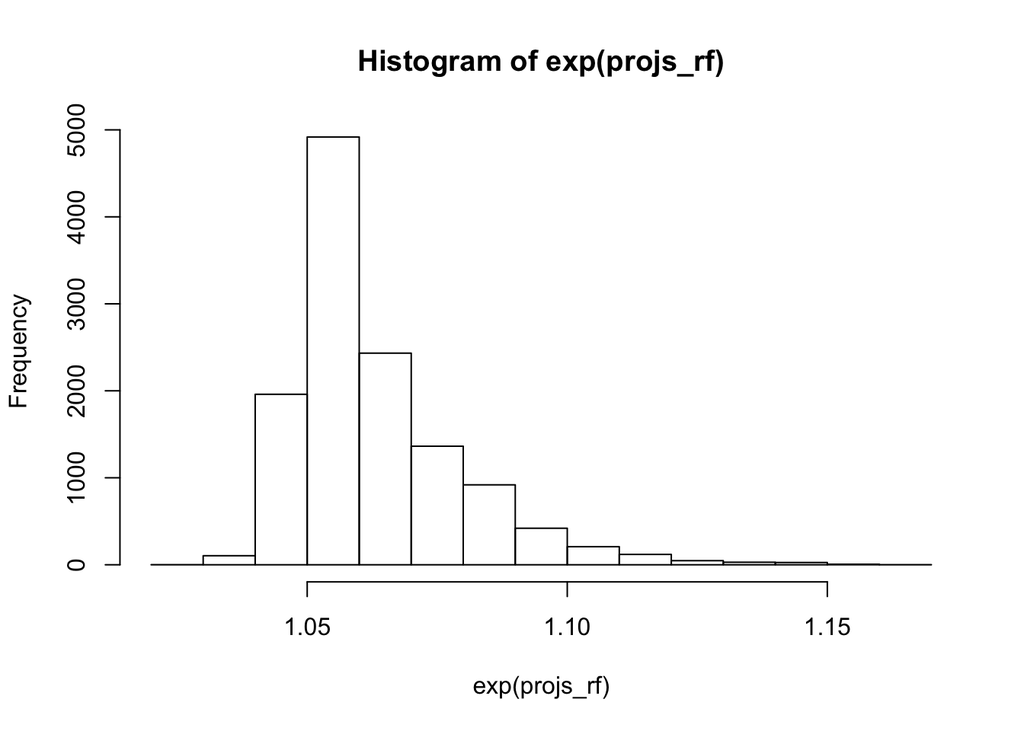

```r
proj_hws <- left_join(proj_hws, proj_pops, by = "city") %>%
  left_join(select(base_deaths, city, mort_rate), by = "city")

# Get predicted log RR for all of the heatwaves. This is for projected
# heat waves under climate change
projs_rf <- predict(rf_mod, newdata = proj_hws)
hist(exp(projs_rf))
```

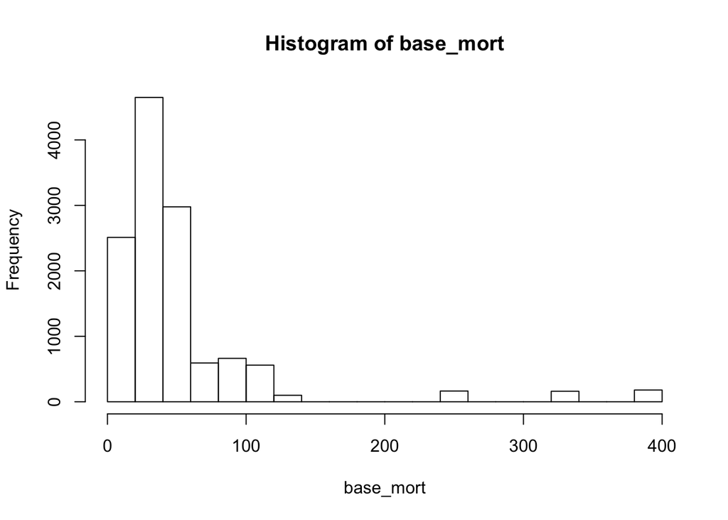

```r
hw_length <- proj_hws$length
base_mort <- proj_hws$pop100 * proj_hws$mort_rate

hist(base_mort)
```

```r
hw_length[1] * base_mort[1] # expected mortality during first HW
```

```
## [1] 80.12611
```

```r
                            # under no-HW counterfactual
exp(projs_rf[1]) - 1 # Percent increase from first heatwave
```

```
##         1
## 0.0584438
```

```r
hw_length[1] * base_mort[1] * (exp(projs_rf[1]) - 1) # Expected excess from HW1
```

```
##        1
## 4.682875
```

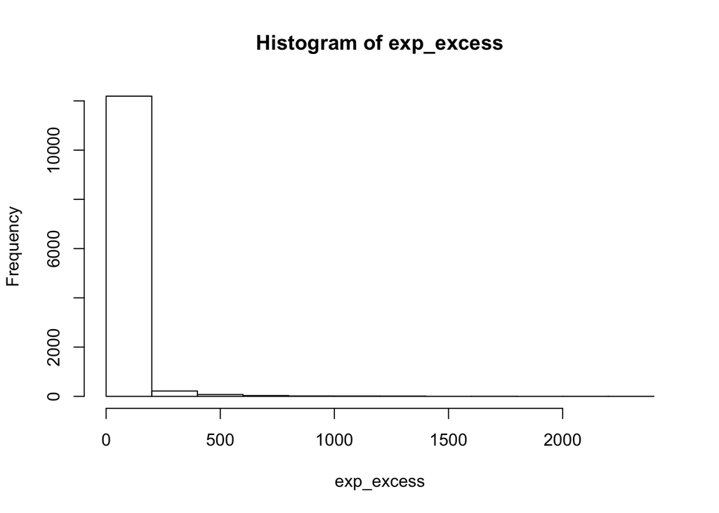

```r
exp_excess <- (exp(projs_rf) - 1) * hw_length * base_mort
hist(exp_excess)
```

```r
summary(exp_excess)
```

```
##     Min.  1st Qu.   Median     Mean  3rd Qu.     Max.
##    1.070    4.641    9.632   33.180   25.110 2389.000
```

```r
## Heat wave with highest expected mortality
proj_hws[exp_excess == max(exp_excess), ]
```

```
##      city mean.temp max.temp min.temp length start.doy start.month
## 7036   ny     90.93    98.62    83.96     46       196           7
##      days.above.80 days.above.85 days.above.90 days.above.95
## 7036            46            41            27             9
##      days.above.99th days.above.99.5th first.in.season mean.temp.quantile
## 7036              40                39               0          0.9997808
##      max.temp.quantile min.temp.quantile mean.temp.1 mean.summer.temp
## 7036                 1         0.9818082     64.8848          81.0758
##        pop100 pop.density    mort_rate
## 7036 18197664 0.009544657 2.106281e-05
```

```r
sum(exp_excess)
```

```
## [1] 416565.8
```

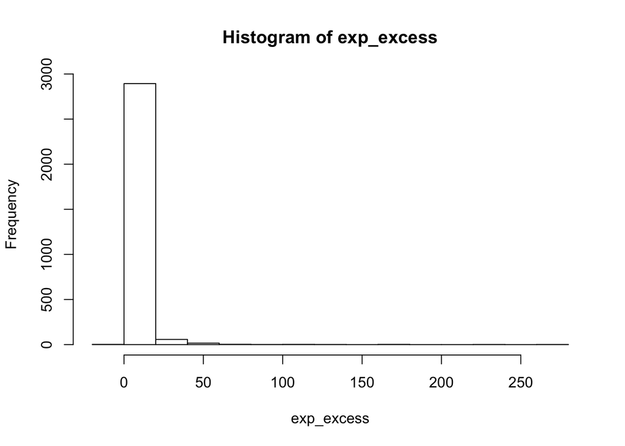

```r
# Here are some estimates of total heat wave-related mortality
# for the historical observed data
hist_hws <- left_join(hw, select(base_deaths, city, mort_rate),
                      by = "city")
hist_rf <- predict(rf_mod, newdata = hist_hws)

hw_length <- hist_hws$length
base_mort <- hist_hws$pop100 * hist_hws$mort_rate

exp_excess <- (exp(hist_rf) - 1) * hw_length * base_mort
hist(exp_excess)
```

```r
summary(exp_excess)
```

```
##    Min. 1st Qu.  Median    Mean 3rd Qu.    Max.
##  -1.628   1.446   2.454   4.588   4.472 276.800
```

```r
## Heat wave with highest expected mortality
as.data.frame(hist_hws[exp_excess == max(exp_excess), ])
```

```
##   hw.number mean.temp max.temp min.temp length start.date   end.date
## 1         6  86.21429       90    83.25      7 1993-07-07 1993-07-13
##   start.doy start.month days.above.80 days.above.85 days.above.90
## 1       188           7             7             4             0
##   days.above.95 days.above.99th days.above.99.5th first.in.season
## 1             0               4                 4               1
##   mean.temp.quantile max.temp.quantile min.temp.quantile mean.temp.1
## 1          0.9959654         0.9994236         0.9827089    55.17687
##   mean.summer.temp  Estimate Std..Error city  pop100    arealand
## 1         70.87553 0.3442924 0.03209087   ny 8931737 11439487272
##    pop.density post.estimate    post.se start.year    mort_rate
## 1 0.0007807812     0.2958646 0.02951463       1993 2.106281e-05
```

```r
sum(exp_excess)
```

```
## [1] 13671.24
```